# Digital Media Use and Trust in Institutions

A data cleaning & descriptive analysis walkthrough in R

Raya

September 2026

## About this project

This project demonstrates a standard applied workflow in survey-based social research: taking a raw, messy data export and turning it into a clean data set ready for descriptive analysis.

**Note on the data:** the survey responses used here are simulated, but the questionnaire items are modeled directly on real survey instruments, the European Social Survey’s media-use module and the standard 0–10 institutional trust battery used in the ESS and World Values Survey. Real cross-national survey exports (raw `.csv`/`.sav` files) commonly contain exactly the kinds of problems handled below: inconsistent category labels, numeric missing-value codes (e.g. `98`/`99` for “don’t know”/“refused”), blank strings, stray whitespace, and duplicate rows from export errors. Simulating this lets the cleaning steps below reflect real research practice while keeping the project self-contained and reproducible for anyone reviewing it.

The research question this mirrors: **does frequency of online news/social media use relate to how much people trust core institutions (parliament, press, science, politicians)?** — a live question in the digital disinformation/media-literacy literature.

## 1. Load the raw data

```r
raw <- read.csv("raw_survey_export.csv", stringsAsFactors = FALSE)
str(raw)
```

```
## 'data.frame':    608 obs. of  9 variables:
##  $ resp_id          : int  1 2 3 4 5 6 7 8 9 10 ...
##  $ country          : chr  "Finland" "Germany" "Finland" "Finland" ...
##  $ age_grp          : chr  "45-54" "65+" "25-34" "45-54" ...
##  $ education        : chr  "secondary " "secondary " "primary" "primary" ...
##  $ net_use_news     : chr  "Several times a week" "Once a week" "Less than once a month" "98" ...
##  $ trust_parliament : int  1 98 99 NA 9 99 9 3 99 7 ...
##  $ trust_press      : int  2 8 1 5 1 5 98 99 2 10 ...
##  $ trust_science    : int  3 8 99 0 0 4 10 10 9 0 ...
##  $ trust_politicians: int  98 4 2 98 9 98 1 99 6 3 ...
```

```r
head(raw, 5)
```

```
##   resp_id country age_grp  education           net_use_news trust_parliament
## 1       1 Finland   45-54 secondary    Several times a week                1
## 2       2 Germany     65+ secondary             Once a week               98
## 3       3 Finland   25-34    primary Less than once a month               99
## 4       4 Finland   45-54    primary                     98               NA
## 5       5 Finland   35-44        phd            Once a week                9
##   trust_press trust_science trust_politicians
## 1           2             3                98
## 2           8             8                 4
## 3           1            99                 2
## 4           5             0                98
## 5           1             0                 9
```

The raw export has 608 rows and 9 columns — already more rows than expected, a first sign of duplicates to check for.

## 2. Clean the data

### 2.1 Remove duplicate and incomplete rows

```r
clean <- raw %>%
  distinct(resp_id, .keep_all = TRUE) %>%     # drop duplicate respondents
  filter(!is.na(country))                     # drop rows with no country recorded

cat("Rows after de-duplication:", nrow(clean), "\n")
```

```
## Rows after de-duplication: 600
```

### 2.2 Standardise the education variable

Raw category labels are inconsistent (`"Secondary"` vs `"secondary "` vs trailing whitespace vs `"NA"` as a literal string).

```r
clean <- clean %>%
  mutate(
    education = trimws(tolower(education)),
    education = na_if(education, "na"),
    education = na_if(education, ""),
    education = recode(education,
                        "phd" = "tertiary"),   # fold PhD into tertiary for this analysis
    education = factor(education,
                        levels = c("primary", "secondary", "tertiary"),
                        ordered = TRUE)
  )

table(clean$education, useNA = "ifany")
```

```
##
##   primary secondary  tertiary      <NA>
##        80       164       211       145
```

### 2.3 Recode internet/social media news use into an ordered factor

```r
clean <- clean %>%
  mutate(
    net_use_news = na_if(net_use_news, "98"),
    net_use_news = na_if(net_use_news, "99"),
    net_use_news = factor(net_use_news,
      levels = c("Never", "Less than once a month", "Once a month",
                 "Several times a month", "Once a week",
                 "Several times a week", "Every day"),
      ordered = TRUE)
  )

table(clean$net_use_news, useNA = "ifany")
```

```
##
##                  Never Less than once a month           Once a month
##                     35                     24                     33
##  Several times a month            Once a week   Several times a week
##                     69                     66                     85
##              Every day                   <NA>
##                    223                     65
```

### 2.4 Clean the trust items (0–10 scales)

Survey exports typically use out-of-range numeric codes for missing data (here `98` = “don’t know”, `99` = “refused”); these need to become proper `NA`s before any averaging, or they will silently wreck the descriptive statistics.

```r
trust_vars <- c("trust_parliament", "trust_press", "trust_science", "trust_politicians")

clean <- clean %>%
  mutate(across(all_of(trust_vars), as.character)) %>%
  mutate(across(all_of(trust_vars), ~ na_if(.x, ""))) %>%
  mutate(across(all_of(trust_vars), ~ suppressWarnings(as.numeric(.x)))) %>%
  mutate(across(all_of(trust_vars), ~ ifelse(.x %in% c(98, 99), NA, .x)))

summary(clean[trust_vars])
```

```
##  trust_parliament  trust_press     trust_science    trust_politicians
##  Min.   : 0.00    Min.   : 0.000   Min.   : 0.000   Min.   : 0.000
##  1st Qu.: 2.00    1st Qu.: 2.000   1st Qu.: 3.000   1st Qu.: 2.000
##  Median : 5.00    Median : 5.000   Median : 5.000   Median : 5.000
##  Mean   : 4.87    Mean   : 5.122   Mean   : 5.074   Mean   : 4.819
##  3rd Qu.: 8.00    3rd Qu.: 8.000   3rd Qu.: 8.000   3rd Qu.: 7.000
##  Max.   :10.00    Max.   :10.000   Max.   :10.000   Max.   :10.000
##  NAs    :153      NAs    :133      NAs    :128      NAs    :146
```

### 2.5 Build a composite trust index

A common step in this literature: average the four trust items into a single institutional trust index per respondent.

```r
clean <- clean %>%
  rowwise() %>%
  mutate(trust_index = mean(c_across(all_of(trust_vars)), na.rm = TRUE)) %>%
  ungroup() %>%
  mutate(trust_index = ifelse(is.nan(trust_index), NA, trust_index))

summary(clean$trust_index)
```

```
##    Min. 1st Qu.  Median    Mean 3rd Qu.    Max.     NAs
##   0.000   3.750   5.000   4.958   6.250  10.000       2
```

## 3. Descriptive analysis

### 3.1 Sample composition

```r
clean %>%
  count(country) %>%
  arrange(desc(n))
```

```
## # A tibble: 6 × 2
##   country       n
##   <chr>     <int>
## 1 "Finland"   249
## 2 "Estonia"    86
## 3 "Sweden"     75
## 4 "Germany"    72
## 5 "Poland"     68
## 6 ""           50
```

```r
clean %>%
  filter(!is.na(education)) %>%
  count(education) %>%
  mutate(pct = percent(n / sum(n)))
```

```
## # A tibble: 3 × 3
##   education     n pct
##   <ord>     <int> <chr>
## 1 primary      80 18%
## 2 secondary   164 36%
## 3 tertiary    211 46%
```

### 3.2 Distribution of the trust index

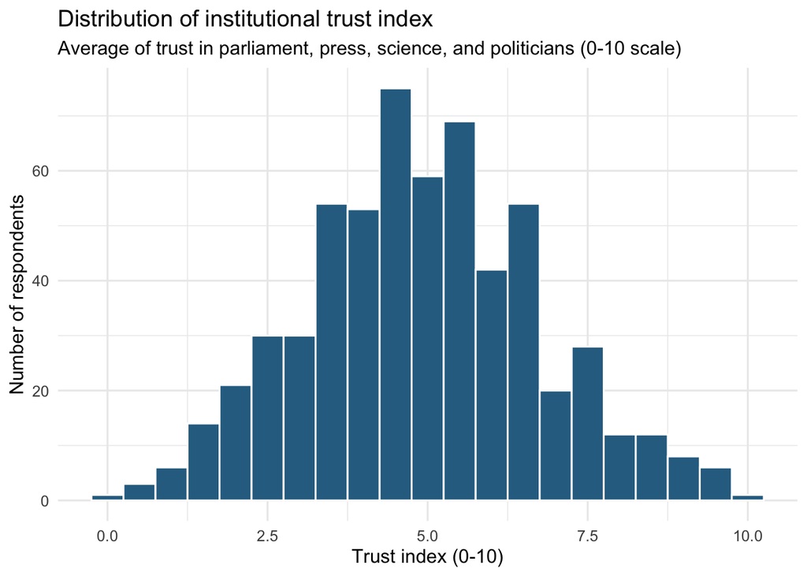

```r
ggplot(clean %>% filter(!is.na(trust_index)), aes(x = trust_index)) +
  geom_histogram(binwidth = 0.5, fill = "#2c6e91", color = "white") +
  labs(title = "Distribution of institutional trust index",
       subtitle = "Average of trust in parliament, press, science, and politicians (0-10 scale)",
       x = "Trust index (0-10)", y = "Number of respondents") +
  theme_minimal(base_size = 12)
```

### 3.3 Trust by frequency of online news/social media use

This is the key descriptive relationship: mean trust index by how often respondents use the internet/social media for news.

```r
by_netuse <- clean %>%
  filter(!is.na(net_use_news), !is.na(trust_index)) %>%
  group_by(net_use_news) %>%
  summarise(
    mean_trust = mean(trust_index, na.rm = TRUE),
    n = n(),
    .groups = "drop"
  )

by_netuse
```

```
## # A tibble: 7 × 3
##   net_use_news           mean_trust     n
##   <ord>                       <dbl> <int>
## 1 Never                        4.89    34
## 2 Less than once a month       4.13    24
## 3 Once a month                 4.63    33
## 4 Several times a month        5.01    69
## 5 Once a week                  4.94    66
## 6 Several times a week         5.02    85
## 7 Every day                    5.08   223
```

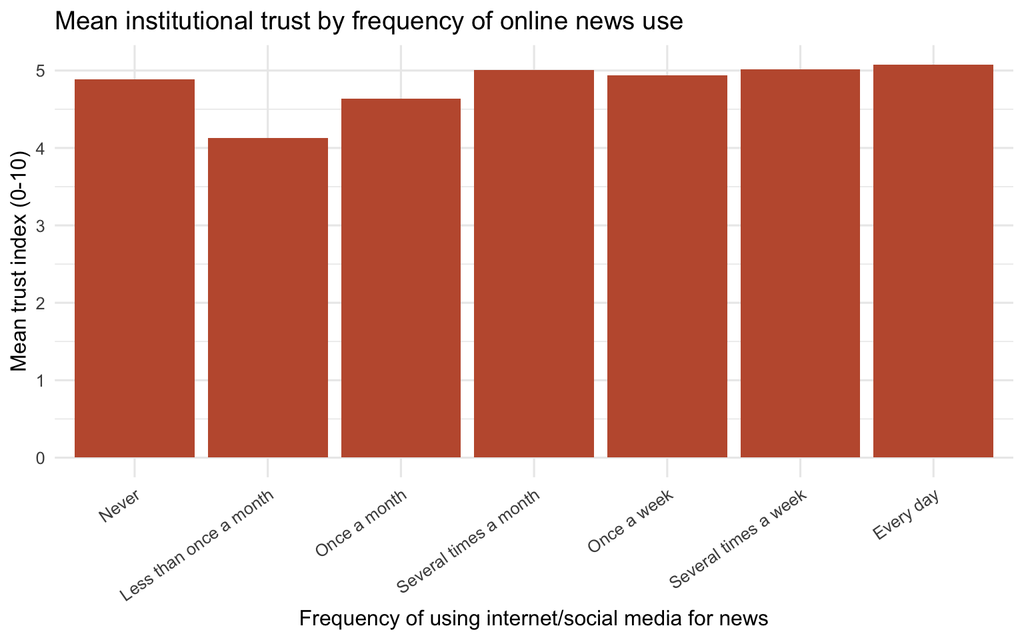

```r
ggplot(by_netuse, aes(x = net_use_news, y = mean_trust)) +
  geom_col(fill = "#c15b3c") +
  labs(title = "Mean institutional trust by frequency of online news use",
       x = "Frequency of using internet/social media for news",
       y = "Mean trust index (0-10)") +
  theme_minimal(base_size = 12) +
  theme(axis.text.x = element_text(angle = 35, hjust = 1))
```

### 3.4 Trust by education level

```r
clean %>%
  filter(!is.na(education), !is.na(trust_index)) %>%
  group_by(education) %>%
  summarise(mean_trust = mean(trust_index), sd_trust = sd(trust_index), n = n(),
            .groups = "drop")
```

```
## # A tibble: 3 × 4
##   education mean_trust sd_trust     n
##   <ord>          <dbl>    <dbl> <int>
## 1 primary         4.94     1.90    80
## 2 secondary       4.76     1.84   164
## 3 tertiary        4.89     1.81   209
```

## 4. Summary

This is the kind of pipeline — cleaning raw survey exports into an analysis-ready dataset and producing clear descriptive summaries — that underlies most applied social science data work in R.